# getarc Deep-Dive

Matthew Whittle

07/12/2021

# Outline:

- Downloading a feature layer
- Perform some analysis in R
- Performing queries:
  - where query
  - spatial query
- Strategies for working with large datasets:
  - Subset columns
  - Limit feature count
  - Return a table
  - Returning less precise geometry

https://craft.co/jacobs/locations

# Feature Layer

ArcGIS host spatial data in ‘Feature Layers’. Below is an example: the [World Countries Feature Layer](https://hub.arcgis.com/datasets/2b93b06dc0dc4e809d3c8db5cb96ba69_0/explore).

[figure not shown]

### How do we access these data in R?

You can download the layer directly in various formats (shapefile, GeoJSON, etc.) which you could read into R locally. But with the `getarc` package, we can query the feature layer to download all or part of it. To do this we need to find the service URL for the layer:

1. Click ‘View Full Details’ to visit the Feature Server Page (this is what our layer sits on)
2. Click the layer we want (sometimes there are more than one on a FS).

[figure not shown]

3. Copy the URL on the right-hand side of the page.

[figure not shown]

Service URL:

`https://services.arcgis.com/P3ePLMYs2RVChkJx/arcgis/rest/services/World_Countries_(Generalized)/FeatureServer/0`

## Downloading Data

The primary function in `getarc` is `query_layer` this does exactly what it says on the tin.

To download the layer, you just need to pass the service url to the endpoint argument of query_layer.

```r
require(getarc)
require(sf)

# Store the service URL in an object
ep_world_countries <- "https://services.arcgis.com/P3ePLMYs2RVChkJx/arcgis/rest/services/World_Countries_(Generalized)/FeatureServer/0"

# Download the layer
world_countries <- query_layer(endpoint = ep_world_countries)

# Print the spatial data frame
world_countries %>% rmarkdown::paged_table()
```

|  | FID | COUNTRY | ISO | COUNTRYAFF | AFF_ISO | Shape__Area | Shape__Length | geometry |
| --- | --- | --- | --- | --- | --- | --- | --- | --- |
| 115 | 115 | Zimbabwe | ZW | Zimbabwe | ZW | 4.387838e+11 | 3.002970e+06 |  |
| 114 | 114 | Zambia | ZM | Zambia | ZM | 8.010726e+11 | 5.538283e+06 |  |
| 111 | 111 | South Africa | ZA | South Africa | ZA | 1.606393e+12 | 8.144655e+06 |  |
| 208 | 208 | Yemen | YE | Yemen | YE | 4.935727e+11 | 3.840309e+06 |  |
| 7 | 7 | Samoa | WS | Samoa | WS | 3.132371e+09 | 3.388218e+05 |  |
| 225 | 225 | Vanuatu | VU | Vanuatu | VU | 1.339262e+10 | 1.870382e+06 |  |
| 232 | 232 | Vietnam | VN | Vietnam | VN | 3.577962e+11 | 7.604244e+06 |  |
| 69 | 69 | Venezuela | VE | Venezuela | VE | 9.328995e+11 | 8.603395e+06 |  |
| 63 | 63 | Saint Vincent and the Grenadines | VC | Saint Vincent and the Grenadines | VC | 3.634117e+08 | 7.363352e+04 |  |
| 179 | 179 | Vatican City | VA | Vatican City | VA | 1.019344e+06 | 3.994234e+03 |  |

[output cut: 239 more lines]

`query_layer` returns a spatial dataframe from the sf library (popular library for vector data in R - similar to `geopandas`). This library has a flexible array of geo-spatial tools and works seamlessly with the tidyverse and other popular R packages.

### Plot the geometry using base R plot:

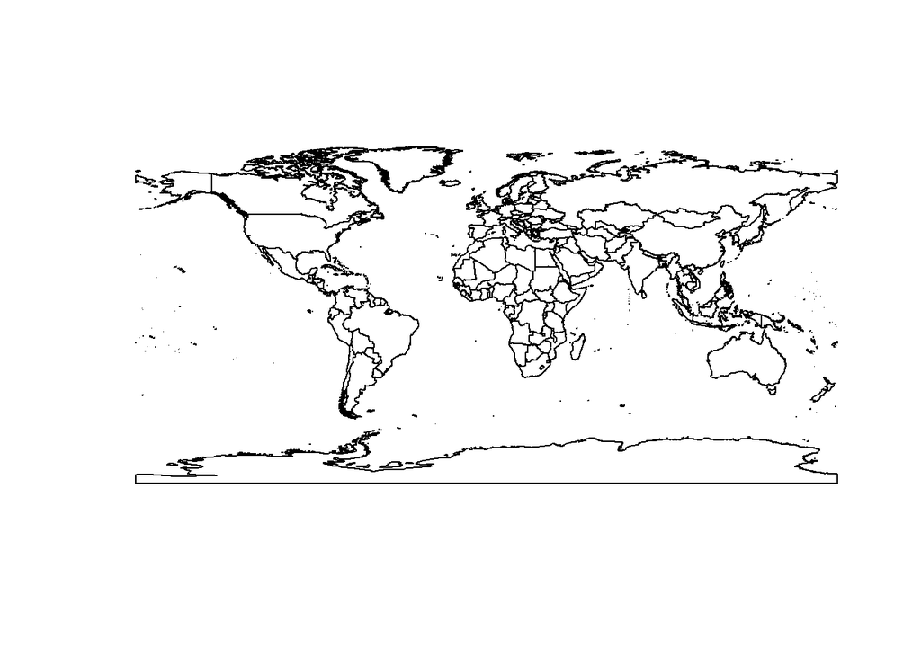

```r
plot(world_countries$geometry)
```

### Use `tidyverse` & `tmap` to plot the UK:

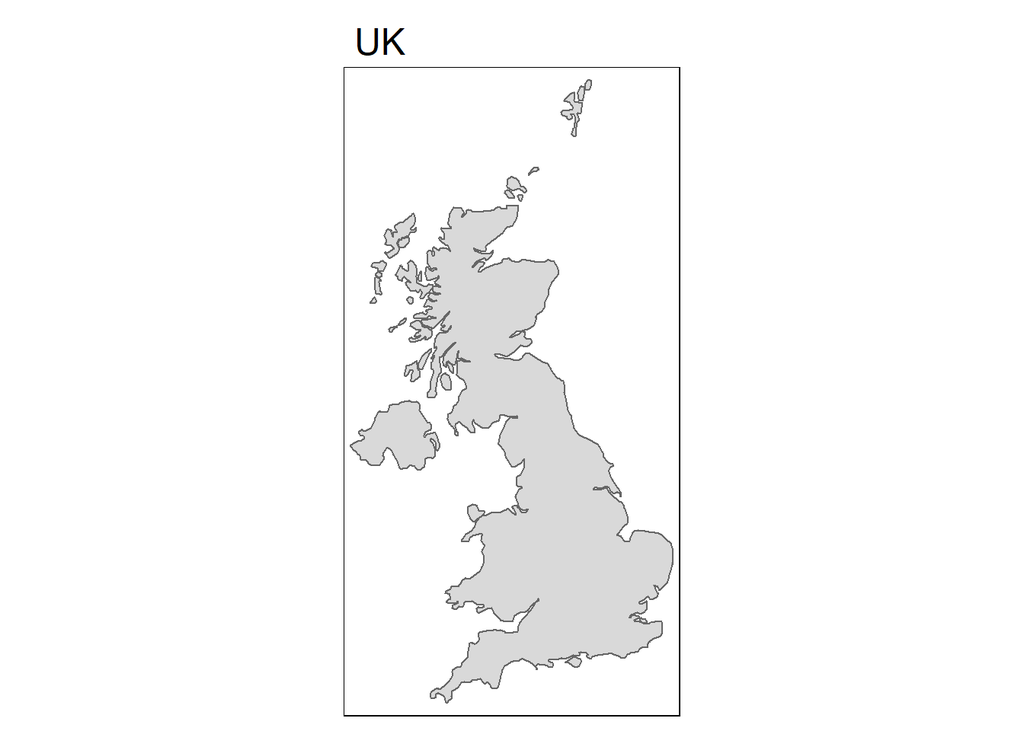

```r
require(tidyverse)
require(tmap)

uk <-
  world_countries %>%
  filter(COUNTRY == "United Kingdom")

uk %>%
  tm_shape() +
  tm_polygons() +
  tm_layout(main.title = "UK")
```

# Queries

Loading a layer directly into R from the API allows you to combine it with all the powerful tools we have at our disposal. However, a powerful aspect of query_layer is the ability to perform more complex queries to return exactly what you want. This is especially helpful when working with very large layers.

## Simple Sub-Setting & Drop Geometry

If we want a quick look at the shape of the dataset or want to check the values in only one column we can use the following arguments:

- `return_n = 1` - return only one row
- `out_fields = "COUNTRY"` - get only the `COUTRY` field
- `return_geometry = FALSE` - don’t return the geometry, only a table

```r
one_country <-
  query_layer(endpoint = ep_world_countries,
              return_n = 1,
              out_fields = "COUNTRY",
              return_geometry = FALSE)

one_country
```

| FID | COUNTRY |
| --- | --- |
| 115 | Zimbabwe |

## SQL Where Query

It is also possible to perform an SQL query on the layer. You need to write the query as a text string (excluding the WHERE keyword) and pass it to the `where` argument:

`where = "COUNTRY ='France'"`

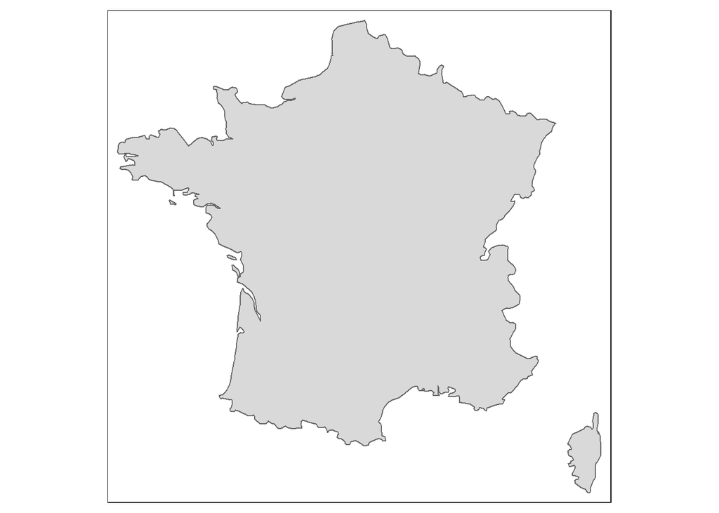

```r
france <-
  query_layer(
  endpoint = ep_world_countries,
  where = "COUNTRY ='France'"
)

france %>%
  tm_shape() +
  tm_polygons()
```

You can use a where query a bit like you would use the `filter` function from `dplyr`:

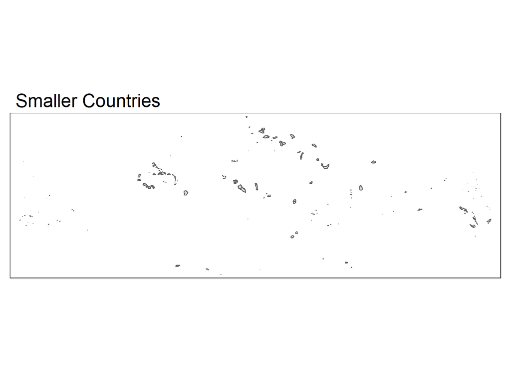

```r
smaller_countries <-
  query_layer(
  endpoint = ep_world_countries,
  where = "Shape__Area < 100189900000"
)

smaller_countries %>%
  tm_shape() +
  tm_polygons() +
  tm_layout(main.title = "Smaller Countries")
```

The Where query supports lots of different options (taken from [documentation](https://developers.arcgis.com/rest/services-reference/enterprise/query-feature-service-layer-.htm)):

```
( '<=' | '>=' | '<' | '>' | '=' | '!=' | '<>' | LIKE )
(AND | OR)
(IS | IS_NOT)
(IN | NOT_IN) ( '(' ( expr ( ',' expr )* )? ')' )
COLUMN_NAME BETWEEN LITERAL_VALUE AND LITERAL_VALUE
```

## Spatial Query

It is also possible to perform a query using spatial data.

I have a feature layer of geocoded Jacobs office locations which I scraped from our website. I’m going to download the location of all of our UK offices by passing in the UK boundary we created earlier to the `in_geometry` argument and specify the the ‘intersects’ spatial filter. This will run a query on the feature layer, returning all the feature which intersect with the geometry I passed in.

- You can pass in any singular geometry to the in_geometry argument (point, lines & polygons - incl multi…)
- There are multiple options for the spatial_filter: *intersects, contains, crosses, envelope_intersects, index_intersects, overlaps, touches, within*

```r
ep_jacobs_offices <- "https://services6.arcgis.com/k3kybwIccWQ0A7BB/arcgis/rest/services/Jacobs_Offices/FeatureServer/0"

jacobs_uk <- query_layer(endpoint = ep_jacobs_offices, in_geometry = uk, spatial_filter = "intersects")

jacobs_uk %>% rmarkdown::paged_table()
```

|  | office_name | address | country | iso | ObjectId | geometry |
| --- | --- | --- | --- | --- | --- | --- |
| 10 | Warrington | 601 Faraday Street Birchwood Park Warrington, England, WA3 6GN | United Kingdom | GB | 192 |  |
| 21 | Peterborough | Endeavour House Forder Way Hampton Peterborough PE7 8GX England | United Kingdom | GB | 209 |  |
| 13 | Edinburgh | 160 Dundee Street Edinburgh EH11 1DQ Scotland | United Kingdom | GB | 195 |  |
| 7 | Newcastle upon Tyne | Partnership House Regent Farm Road Gosforth Newcastle Upon Tyne NE3 3AF England | United Kingdom | GB | 189 |  |
| 24 | Worcester | Red Hill House 227 London Road Worcester WR5 2JG England | United Kingdom | GB | 212 |  |
| 8 | Reading | 1180 Eskdale Road Winnersh Wokingham RG41 5TU England | United Kingdom | GB | 190 |  |
| 25 | Glasgow | 95 Bothwell Street Glasgow G2 7HX Scotland | United Kingdom | GB | 213 |  |
| 2 | Cumbria | Pillar House Ingwell Drive Westlakes Science & Technology Park Moor Row Cumbria, CA24 3HW England | United Kingdom | GB | 184 |  |
| 19 | Leeds | 1 City Walk, Leeds West Yorkshire LS11 9DX England | United Kingdom | GB | 207 |  |
| 11 | York | 20 George Hudson Street York YO1 6WR England | United Kingdom | GB | 193 |  |

[output cut: 15 more lines]

#### Map of Jacobs UK Offices:

```r
# Load the leaflet package and leafem extension (mapping SF features)
require(leaflet)
require(leafem)

# Create a simple leafelet map
# Use Jacobs colour scheme
leaflet() %>%
  addTiles() %>%
  addFeatures(uk, color = colours$blue, fill = NA) %>%
  addFeatures(
    jacobs_uk,
    color = colours$pink,
    fillOpacity = 0.7,
    fillColor = colours$yellow,
    popup = ~ office_name
  )
```

[interactive chart not shown]

## Analysis Pipeline

Which UK Office has the most Green Space within a 1km radius?

```r
ep_os_greenspace <- "https://services5.arcgis.com/piNGxor37zqmvRAm/arcgis/rest/services/OS_Open_Greenspace/FeatureServer/1"

# Transform the Office locations to British National Grid (units: m) to buffer to 1km (1000m)
jacobs_uk_1km <- jacobs_uk %>% st_transform(crs = 27700) %>% st_buffer(1000)

# Get the greenspace data.
# Union the buffered office locations as in_geometry only accepts combined geometries
# This conversts it into a multipolygon
greenspace <- query_layer(endpoint = ep_os_greenspace, in_geometry = st_union(jacobs_uk_1km))

greenspace <-
  greenspace %>%
  mutate(popup = glue::glue("{distName1} ({function_})"))

# Map the data
greenspace_map <-
  leaflet() %>%
  addTiles() %>%
  addFeatures(uk, color = colours$blue, fill = NA) %>%
  addFeatures(greenspace, color = colours$dark_green, fillOpacity = 0.9, popup = ~popup) %>%
  addFeatures(
    jacobs_uk,
    color = colours$pink,
    fillOpacity = 0.7,
    fillColor = colours$yellow,
    popup = ~ office_name
  )

greenspace_map
```

[interactive chart not shown]

```r
greenspace_jc <- greenspace %>% st_join(jacobs_uk_1km %>% st_transform(crs = 4326))

# Define a function to convert m2 to hectares
to_hectares <-
  function(x){
    x_ha <- x / 10000
    units::as_units(as.numeric(x_ha), "ha")
  }


greenspace_summary <-
  greenspace_jc %>%
  mutate(area_ha = geometry %>% st_area() %>% to_hectares()) %>%
  st_drop_geometry() %>%
  group_by(office_name) %>%
  summarise(total_greenspace_area_ha = sum(area_ha) %>% round(1))

greenspace_summary <-
  greenspace_summary %>%
  arrange(desc(total_greenspace_area_ha))

greenspace_summary %>% rmarkdown::paged_table()
```

| office_name | total_greenspace_area_ha |
| --- | --- |
| Warrington | 235.5 [ha] |
| Newcastle upon Tyne | 119.8 [ha] |
| Exeter | 104.5 [ha] |
| Cardiff | 60.2 [ha] |
| Humber | 56.1 [ha] |
| Southampton | 50.5 [ha] |
| Gloucester | 49.8 [ha] |
| Worcester | 49.8 [ha] |
| Stockton on Tees | 37.7 [ha] |
| Bristol | 35.6 [ha] |

[output cut: 15 more lines]

```r
# Make an icon to highlight offices with a lot of greenspace
greenLeafIcon <- makeIcon(
  iconUrl = "https://leafletjs.com/examples/custom-icons/leaf-green.png",
  iconWidth = 38, iconHeight = 95,
  iconAnchorX = 22, iconAnchorY = 94,
  shadowUrl = "https://leafletjs.com/examples/custom-icons/leaf-shadow.png",
  shadowWidth = 50, shadowHeight = 64,
  shadowAnchorX = 4, shadowAnchorY = 62
)

top_3 <- jacobs_uk %>%
  left_join(greenspace_summary) %>%
  slice_max(order_by = total_greenspace_area_ha, n = 3) %>%
  mutate(long = st_coordinates(geometry)[,1],
         lat = st_coordinates(geometry)[,2])

greenspace_map %>%
  addMarkers(lng = top_3$long, lat = top_3$lat,
              icon = greenLeafIcon)
```

[interactive chart not shown]

# Under the hood of `query_layer`

A lot happens under the hood of `query_layer` to provide a smooth experience for the user. Feature layers have a limit on how many records they will return per query (generally around 2,000), so if you want to download many features the function needs to get around this limit.

The function executes the following broad steps:

1. Get the ‘layer details’ - json object which gives us a lot of useful info about the layer to inform the subsequent query
   - Field names & their data types, Feature ID field, field ‘domains’ (like a factor in R) & their encoding, etc.
2. Parse function arguments into a query which matches the API specification
   - simple: `geometry_precision = 1` -> `geometryPrecision=1` or more complex parsing & encoding of spatial data
3. **Get a list of feature IDs** matching the query, **split that into n lists** which are less than the query limit, then **perform multiple requests to get all the data** matching the query.
4. Combine the data & parse the variables, swapping domain codes for their values & parsing datetimes
5. Return the dataset with a spatial transformation if requested.

# Wrap up

- `getarc::query_layer` provides a simple & powerful way to get data from ArcGIS into R in a useful format.
- You can perform various queries to get only the data you need, making it easier to work with large datasets or minimising processing time.
- You can also authenticate via OAuth2.0 to query data on private ArcGIS Online servers (e.g. Jacobs project data).
- There is a lot more you can do with the ArcGIS API & the Python API supports all of this.